# RSample Demo

```r
library(ggplot2)
library(dplyr)
GrinnellHouses <- read.csv("https://grinnell-sta-295-s24.github.io/data/GrinnellHouses.csv")
```

Codebook for data:

https://grinnell-sta-295-s24.github.io/data/GrinnellHouses_codebook.txt

We start with data exploration:

```r
glimpse(GrinnellHouses)
```

```
## Rows: 929
## Columns: 17
## $ Date        <int> 16695, 16880, 16875, 16833, 16667, 16583, 16602, 16687, 16…
## $ Address     <chr> "1510 First Ave #112 ", "1020 Center St ", "918 Chatterton…
## $ Bedrooms    <int> 2, 3, 4, 3, 3, 3, 2, 2, 3, 3, 5, 4, 3, 2, 2, 2, 3, 4, 4, 2…
## $ Baths       <dbl> 1.00, 1.00, 1.00, 1.00, 1.00, 1.00, 1.00, 1.50, 2.00, 2.00…
## $ SquareFeet  <int> 1120, 1224, 1540, 1154, 1277, 1079, 768, 1152, 912, 1488, …
## $ LotSize     <dbl> NA, 0.1721763, NA, NA, 0.2066116, 0.1993572, NA, NA, 0.218…
## $ YearBuilt   <int> 1993, 1900, 1970, 1900, 1900, 1900, 1955, 1900, 1900, 1900…
## $ YearSold    <int> 2005, 2006, 2006, 2006, 2005, 2005, 2005, 2005, 2005, 2005…
## $ MonthSold   <int> 9, 3, 3, 2, 8, 5, 6, 9, 9, 9, 8, 3, 3, 12, 8, 5, 1, 3, 4, …
## $ DaySold     <int> 16, 20, 15, 1, 19, 27, 15, 8, 21, 23, 30, 17, 22, 2, 16, 2…
## $ CostPerSqFt <dbl> 6.25, 22.06, 18.18, 26.00, 24.08, 38.92, 59.90, 42.97, 54.…
## $ OrigPrice   <int> 17000, 35000, 54000, 65000, 35000, 45900, 62500, 54500, 59…
## $ ListPrice   <int> 10500, 35000, 47000, 49000, 35000, 45900, 56500, 52500, 52…
## $ SalePrice   <int> 7000, 27000, 28000, 30000, 30750, 42000, 46000, 49500, 500…
## $ SPLPPct     <dbl> 66.67, 77.14, 59.57, 61.22, 87.86, 91.50, 81.42, 94.29, 95…
## $ Latitude    <dbl> 41.73880, 41.74558, 41.74404, 41.74503, 41.74041, 41.81942…
## $ Longitude   <dbl> -92.71378, -92.73168, -92.71308, -92.72896, -92.73002, -92…
```

Let’s plot Latitude and Longitude

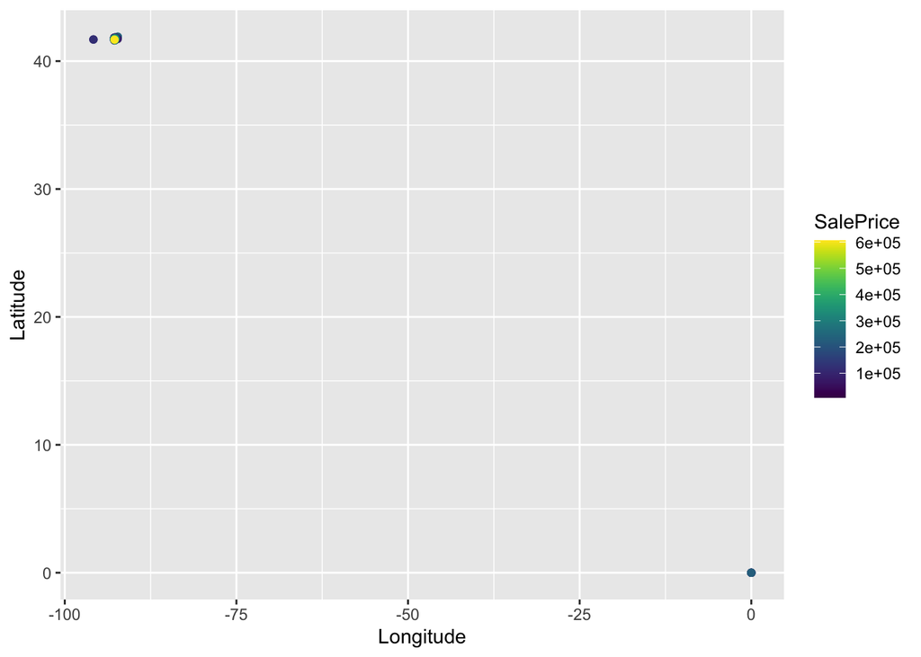

```r
ggplot(GrinnellHouses, aes( x = Longitude, y = Latitude, color = SalePrice)) +
  geom_point() +
  viridis::scale_color_viridis()
```

Removing houses with erroneous coordinates:

```r
GrinnellHouses <- GrinnellHouses %>%
  filter(Latitude != 0, Longitude != 0)
```

And plotting again:

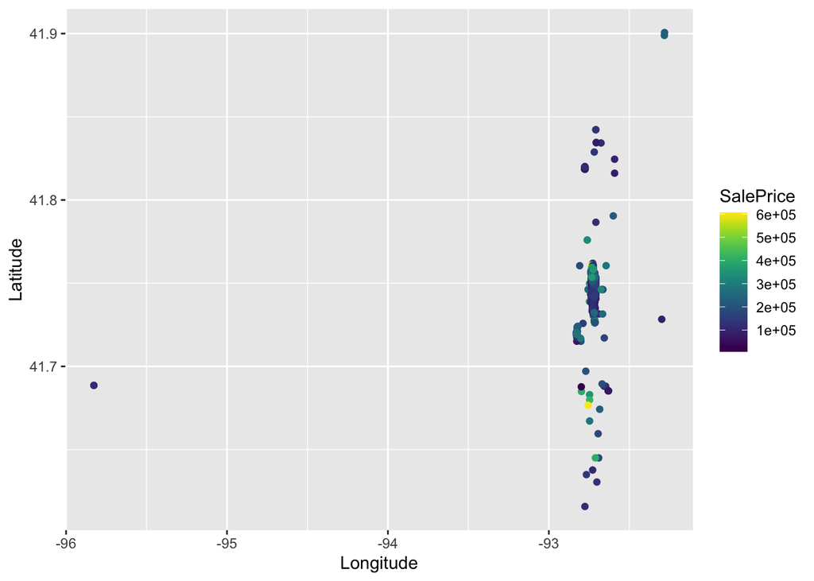

```r
ggplot(GrinnellHouses, aes( x = Longitude, y = Latitude, color = SalePrice)) +
  geom_point() +
  viridis::scale_color_viridis()
```

We still have some houses with atypical coordinates, but these are less likely to be data error. Still, it may be best to remove them

```r
GrinnellHouses <- GrinnellHouses %>%
  filter(Longitude > -94, Longitude < -92.5, Latitude < 41.85)
```

Plotting once more:

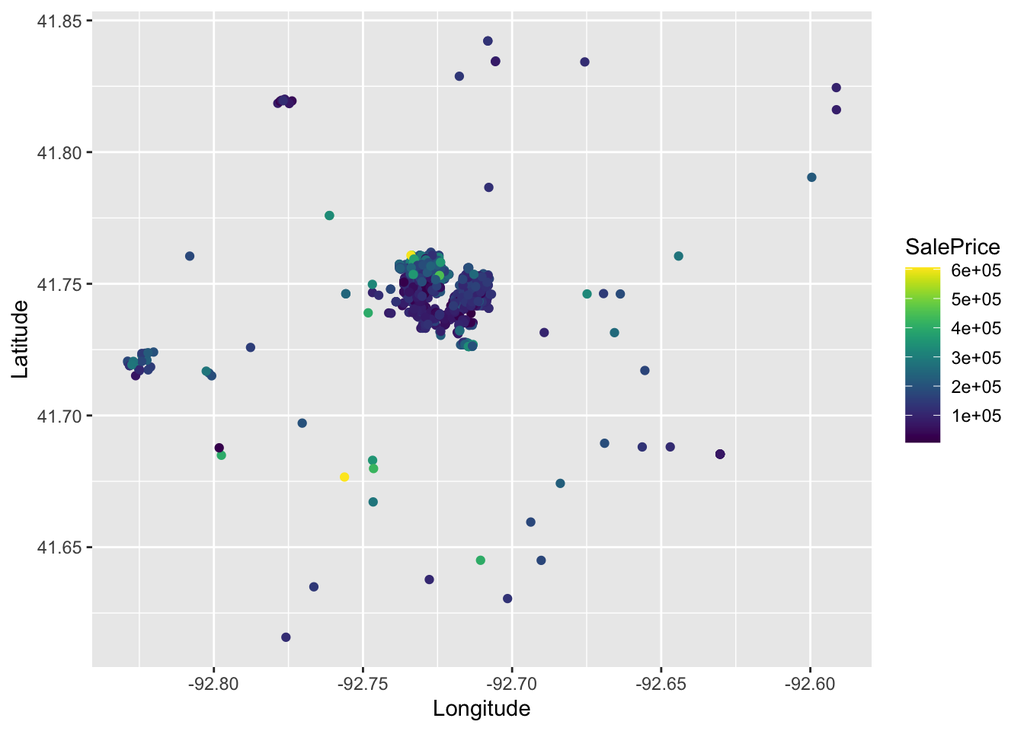

```r
ggplot(GrinnellHouses, aes( x = Longitude, y = Latitude, color = SalePrice)) +
  geom_point() +
  viridis::scale_color_viridis()
```

Do we have any NA data?

```r
colSums(is.na(GrinnellHouses))
```

```
##        Date     Address    Bedrooms       Baths  SquareFeet     LotSize
##           0           0           0           0          18         187
##   YearBuilt    YearSold   MonthSold     DaySold CostPerSqFt   OrigPrice
##           0           0           0           0           0           0
##   ListPrice   SalePrice     SPLPPct    Latitude   Longitude
##           0           0           0           0           0
```

This is fine, but we should be cautious depending on which models we use.

## Model Building with Functions

Goal: write a function that will build a model on a supplied training set.

Suggestions: KNN model

This function will take as input a training data set, a test data set, the number of neighbors desired, and a number corresponding to the distance metric, and will output the knn model object, which can be used to find fitted values.

```r
get_that_model <- function(the_training_data, the_test_data, how_many_neighbors, distance_number){
  library(kknn)
  kknn(SalePrice ~ Latitude + Longitude, train = the_training_data,
       test = the_test_data, distance = distance_number, k =how_many_neighbors, kernel = "rectangular")
}
```

## Test and Training Sets Using RSample

We now split our data into test and training sets using functions from `rsample`

```r
set.seed(100)
library(rsample)
my_split <- initial_split(GrinnellHouses)
Grinnell_train <- training(my_split)
Grinnell_test <- testing(my_split)
```

## Get that model

Now, let’s quickly build our models for a variety of different k’s, along with different distance metrics

```r
knn_out_15k <- get_that_model(Grinnell_train, Grinnell_test, 15, 2)

knn_out_5k <- get_that_model(Grinnell_train, Grinnell_test, 5, 2)

knn_out_5k_man <- get_that_model(Grinnell_train, Grinnell_test, 5, 1)
```

We can arrange the predictions from these models as columns in a data frame

```r
pred_data_frame <- data.frame(the_5 = knn_out_5k$fitted.values,
the_15 = knn_out_15k$fitted.values,
the_5_man = knn_out_5k_man$fitted.values)

head(pred_data_frame)
```

```
##   the_5   the_15 the_5_man
## 1 99400 93577.93     89400
## 2 57260 59663.33     57260
## 3 62000 67000.00     62400
## 4 73200 83800.00     73200
## 5 62160 68133.33     62160
## 6 72060 97626.67     72060
```

## Cross-Validation Splits

Now, we use `rsample` to perform 10-fold cross validation using the `vfold_cv` function.

```r
set.seed(9432)
my_fold <- vfold_cv(Grinnell_train, v = 10)
```

Note that the output of the `vfold_cv` function is a data frame; the first element is a “Split” indicating how data was partitioned, and the second element is the “Fold” used for validation.

Let’s look at the first element of splits:

- Note that `splits` is a list, so to access the first element, we need to use the `[[ ]]` notation, rather than the `[ ]` notation used for vectors or data frames.

```r
my_fold$splits[[1]]
```

```
## <Analysis/Assess/Total>
## <619/69/688>
```

To get training set, apply `analysis` function to one of splits:

```r
analysis(my_fold$splits[[1]]) %>% head()
```

```
##    Date       Address Bedrooms Baths SquareFeet    LotSize YearBuilt YearSold
## 1 19327 408 16th Ave         3   3.5       2399  0.2203857      1989     2012
## 2 18624  1211 Hamlin         2   1.0       1152  0.3575758      1986     2010
## 3 17310 1923 Reed St         4   3.0       2330         NA      1999     2007
## 4 19047 1909 Reed St         3   3.0       4240  0.2647383      2001     2012
## 5 19277 4259 20th St         4   3.0       3922 21.9100000      1991     2012
## 6 18032 1120 West St         3   2.0       1799  0.2840909      1900     2009
##   MonthSold DaySold CostPerSqFt OrigPrice ListPrice SalePrice SPLPPct Latitude
## 1        11      30      116.72    299900    285000    280000   98.25 41.76062
## 2        12      28       23.52     30000     30000     27100   90.33 41.74810
## 3         5      24      163.09    399900    399900    380000   95.02 41.75820
## 4         2      24       70.17    359000    324000    297500   91.82 41.75767
## 5        10      11      108.36    455000    455000    425000   93.41 41.67986
## 6         5      15       49.47    102000     89900     89000   99.00 41.74700
##   Longitude
## 1 -92.73036
## 2 -92.72959
## 3 -92.73296
## 4 -92.73294
## 5 -92.74646
## 6 -92.72720
```

To get test set, instead apply `assessment` function

```r
assessment(my_fold$splits[[1]]) %>% head()
```

```
##    Date              Address Bedrooms Baths SquareFeet   LotSize YearBuilt
## 1 17353         321 4th Ave         5  2.50       2050 0.1928375      1900
## 2 16832     409 Park Street         3  1.75       1064        NA      1971
## 3 18375 1417 Michael Avenue         4  3.00       2905 0.2871901      2003
## 4 17198         409 5th Ave         3  2.00       1678        NA      1900
## 5 19792            1623 3rd         4  2.00       1576 0.0355831      1900
## 6 16982       12 Melrose Ln         3  2.00       1341 0.2375803      2006
##   YearSold MonthSold DaySold CostPerSqFt OrigPrice ListPrice SalePrice SPLPPct
## 1     2007         7       6       68.29    148000    148000    140000   94.59
## 2     2006         1      31      106.67    115900    115900    113500   97.93
## 3     2010         4      23      101.38    299900    299900    294500   98.20
## 4     2007         2       1       53.93     94900     89000     90500  101.69
## 5     2014         3      10       38.07     80000     80000     60000   75.00
## 6     2006         6      30      132.74    161900    161900    178000  109.94
##   Latitude Longitude
## 1 41.74337 -92.73204
## 2 41.73642 -92.72261
## 3 41.72700 -92.71491
## 4 41.74485 -92.73120
## 5 41.74186 -92.71235
## 6 41.73429 -92.71336
```

## Putting it all together

Now let’s use functions to build a model on splits. We’ll create prediction on the test set and then compute the test RMSE. Our function will output this RMSE

```r
my_cv_model <- function(split){
  mod <- lm(SalePrice ~ Latitude + Longitude, data = analysis(split))
  validation_set <- assessment(split)
  pred <- predict(mod, newdata = validation_set)
  rmse <- sqrt(mean((validation_set$SalePrice - pred)^2) )
  rmse
}
```

Let apply to the first split, to test functionality:

```r
my_cv_model(my_fold$splits[[1]])
```

```
## [1] 94376.73
```

To apply a function to each element of a list or vector, use the `map_dbl` from the `purrr` package

```r
library(purrr)

map_dbl(my_fold$splits, my_cv_model)
```

```
##  [1] 94376.73 86427.95 72153.23 76523.70 77138.36 71094.67 66483.30 78088.23
##  [9] 62486.97 67344.22
```

Let’s attach this to the data frame of splits:

```r
my_fold$rmse <- map_dbl(my_fold$splits, my_cv_model)
```

And look at the results:

```r
my_fold
```

```
## #  10-fold cross-validation
## # A tibble: 10 × 3
##    splits           id       rmse
##    <list>           <chr>   <dbl>
##  1 <split [619/69]> Fold01 94377.
##  2 <split [619/69]> Fold02 86428.
##  3 <split [619/69]> Fold03 72153.
##  4 <split [619/69]> Fold04 76524.
##  5 <split [619/69]> Fold05 77138.
##  6 <split [619/69]> Fold06 71095.
##  7 <split [619/69]> Fold07 66483.
##  8 <split [619/69]> Fold08 78088.
##  9 <split [620/68]> Fold09 62487.
## 10 <split [620/68]> Fold10 67344.
```

To get cross-validated RMSE, take average of the rmse column:

```r
mean(my_fold$rmse)
```

```
## [1] 75211.74
```